# Spatiotemporal Patterns of Influenza Activity in the United States

BMIN503/EPID600 Final Project

Author

Grace Li

Published

November 25, 2023

### Overview

Season influenza viruses continues to be a major global burden. There are around a billion cases annually and up to 650,000 people die of influenza. Influenza activity patterns vary geographically and temporally, so we want to examine the spatiotemporal patterns of influenza activity in the United States and determine if variations in influenza activities across states or regions are associated with distribution of circulating virus strains. I will be using surveillance data published by the Centers for Disease Control and Prevention (CDC) and viral sequences from the Global Initiative on Sharing All Influenza Data (GIDSAID) to answer these questions. Understanding patterns of seasonal influenza activity can help guide early influenza surveillance and inform influenza prevention and control programs. Materials for this project can be found in [this GitHub repository](https://github.com/graceshli/BMIN503_Final_Project).

### Introduction

Influenza has a large seasonal burden in the United States: up to 35 million people are infected annually causing between 12,000 and 56,000 deaths. In the U.S., flu season typically starts on the 40th week of the year (1st week of October), but influenza activity including time of onset, duration, and number of peaks varies greatly across the states.

The CDC routinely publishes weekly reports of influenza surveillance data providing a national picture of influenza virus activities in the U.S. One aspect of these surveillance is performed by clinical laboratories across the country determining the percentage of specimens positive for influenza virus. These test results allow us to evaluate if influenza cases are increasing or decreasing. Efforts by public health laboratories to sequence influenza genomes have also allowed researchers to study sequences of influenza viruses using databases like GISAID. By linking regional epidemiologic data to circulating influenza sequencing data, we hope to identify patterns of clade distribution associated with influenza activities in the U.S. An understanding of the spatial and temporal spread of influenza can help inform public health decisions in influenza prevention and control.

### Methods

#### Data source

| Datasets | Time range | Source |
| --- | --- | --- |
| Influenza surveillance | 2010-present | [FluView](https://gis.cdc.gov/grasp/fluview/fluportaldashboard.html) |
| Influenza sequencing data | 2010-10-01 to 2019-10-01 | [GISAID](https://gisaid.org) |

*Influenza surveillance*

We obtained influenza surveillance data from the CDC Weekly U.S. Influenza Surveillance Report. Viral surveillance from approximately 300 clinical laboratories in the U.S. World Health Organization (WHO) Collaborating Laboratories System and the National Respiratory and Enteric Virus Surveillance System (NREVSS) is reported weekly and data can be accessed through FluView Interactive.

For this project, I downloaded data from all 50 states starting from the 2010-11 season. Data from clinical laboratories include the weekly total number of specimens tested, the number of positive influenza tests, and the percent positive by influenza type.

*GISAID*

Within the EpiFlu database in GISAID, I searched for human influenza A and influenza B viruse isolates collected in the United States from October 2010 to October 2019. I further filtered isolate selection by requiring the isolate to contain complete sequences of both the hemagglutinin and neuraminidase segment and not been passaged in cells or eggs. I downloaded the virus metadata that contains information including isolate name, subtype, and clade.

#### Download and clean data

First, we will download the weekly U.S. Influenza Surveillance Report. Data collection from both the U.S. WHO Collaborating Laboratories System and NREVSS began during the 1997-98 season. The total number of respiratory specimens tested and %positive rate for influenza are reported weekly.

```r
# Load WHO/NREVSS surveillance data from clinical labs
clinical_labs <- read_csv("WHO_NREVSS_Clinical_Labs.csv")
```

Next, I will clean the surveillance data by removing unused variables and renaming variables. Influenza season typically starts on week 40 (first week of October), so I will include a variable named “ordered_week” that arrange weeks starting with week 40.

```r
# Rename variables and order week variable
clinical_labs <- clinical_labs |>
        dplyr::select(-c("REGION TYPE")) |>
        dplyr::rename(state = REGION,
               year = YEAR,
               week = WEEK,
               total_specimens = `TOTAL SPECIMENS`,
               total_A = `TOTAL A`,
               total_B = `TOTAL B`,
               percent_positive = `PERCENT POSITIVE`,
               percent_A = `PERCENT A`,
               percent_B = `PERCENT B`) |>
        mutate(ordered_week = (week - 40) %% 52 + 1) |>
        mutate(season = ifelse(week >= 40, year, year - 1)) |>
        mutate(ordered_week = as.factor(ordered_week)) |>
        mutate(percent_positive = as.numeric(percent_positive))
```

Since I will be drawing maps, I will retrieve shapefile for all states using tigris() and obtain information on states using the R Datasets Package.

```r
# Retrieve shapefile for all states using tigirs()
states <- states()

# Obtain state information on names and division using the package datasets
states_division <- data.frame(NAME = datasets::state.name,
                              division = datasets::state.division)

# Merge shapefile with state information
states <- inner_join(states, states_division, by = "NAME") |>
            rename(state = NAME)
```

Now I will merge the shapefile data frame with surveillance data.

```r
# Include state division info in clinical_labs df
clinical_labs <- inner_join(states, clinical_labs, by = "state")
```

Finally, I am going to download influenza sequencing data from GISAID.

```r
# Load data for influenza A and influenza B viruses
gisaid_a <- read_csv("gisaid_epiflu_isolates_fluA.csv")
gisaid_b <- read_csv("gisaid_epiflu_isolates_fluB.csv")

# Combine data for influenza A and influenza B viruses
gisaid <- bind_rows(gisaid_a, gisaid_b)

# Select relevant variables and rename variables
gisaid <- gisaid |>
            dplyr::select(c("Isolate_Id", "Isolate_Name",
                            "Subtype", "Clade", "Collection_Date")) |>
            rename(id = Isolate_Id,
                   name = Isolate_Name,
                   subtype = Subtype,
                   clade = Clade,
                   collection_date = Collection_Date)

# Convert 'collection_date' to Date format
gisaid$collection_date <- as.Date(gisaid$collection_date)

# Create a new column 'week' indicating the week of the year
gisaid$week <- week(gisaid$collection_date)

# Create a new column 'season' indicating the flu season from which the isolate was sequenced
gisaid$season <- ifelse(gisaid$week >= 40, year(gisaid$collection_date),
                        year(gisaid$collection_date) - 1)
```

Next we will clean up the GISAID dataset.

```r
# Group by 'subtype' and count the occurrences of each subtype
gisaid |>
  group_by(subtype) |>
  count()
```

```
# A tibble: 6 × 2
# Groups:   subtype [6]
  subtype      n
  <chr>    <int>
1 A           52
2 A / H1N1  6259
3 A / H1N2     8
4 A / H3       6
5 A / H3N2 10703
6 B         5660
```

```r
# Remove rows where 'subtype' is "A", "A / H1N2", or "A / H3" (incomplete sequencing)
gisaid <- gisaid |>
            filter(!(subtype %in% c("A", "A / H1N2", "A / H3")))

# Group by 'subtype' and summarize the count of rows with NAs in 'clade'
gisaid |>
  group_by(subtype) |>
  summarize(na_count = sum(is.na(clade)))
```

```
# A tibble: 3 × 2
  subtype  na_count
  <chr>       <int>
1 A / H1N1        0
2 A / H3N2        0
3 B            3434
```

```r
# Remove rows where 'clade' or 'collection_date' is NA or if clade is unassigned
gisaid <- gisaid |>
            filter(!is.na(clade) & !is.na(collection_date)) |>
            filter(!(clade %in% c("unassigned")))
```

### Results

#### Exploratory data analysis

I will start with some exploratory data analysis by looking at the CDC surveillance data in the 2017-18 flu season.

```r
# Filter data from the 2017-18 season
season2017 <- clinical_labs |>
                filter(season == "2017")

# Set up theme for graphing maps
my_theme <- function() {
  theme_minimal() +
  theme(axis.line = element_blank(),
        axis.text = element_blank(),
        axis.title = element_blank(),
        panel.grid = element_line(color = "white"),
        legend.key.size = unit(0.4, "cm"),
        legend.text = element_text(size = 8),
        legend.title = element_text(size = 10),
        plot.title = element_text(size = 12))
}

# Create a color palette function
myPalette <- colorRampPalette(brewer.pal(9, "YlOrRd"))

# Function to create a single map for a given week
create_weekly_map <- function(week_data) {

  weekly_map <- week_data |>
    st_simplify() |>
    ggplot() +
    geom_sf(aes(fill = percent_positive)) +
    my_theme() +
    labs(title = paste("Week", unique(week_data$week))) +
    scale_fill_gradientn(name = "% Positive", colours = myPalette(100),
                         limit = range(0, 70))
  #return(weekly_map)
}

# Create a list to store individual plots
season2017_map_list <- list()

# Create plots for each week
unique_week <- unique(season2017$week)

for (i in unique_week) {
  # Filter data for the specific week and shift geometry
  week_data <- season2017 |>
    filter(week == i) |>
    shift_geometry()

  # Create a weekly map and add it to the list
  weekly_map <- create_weekly_map(week_data)

  season2017_map_list[[length(season2017_map_list) + 1]] <- weekly_map
}
```

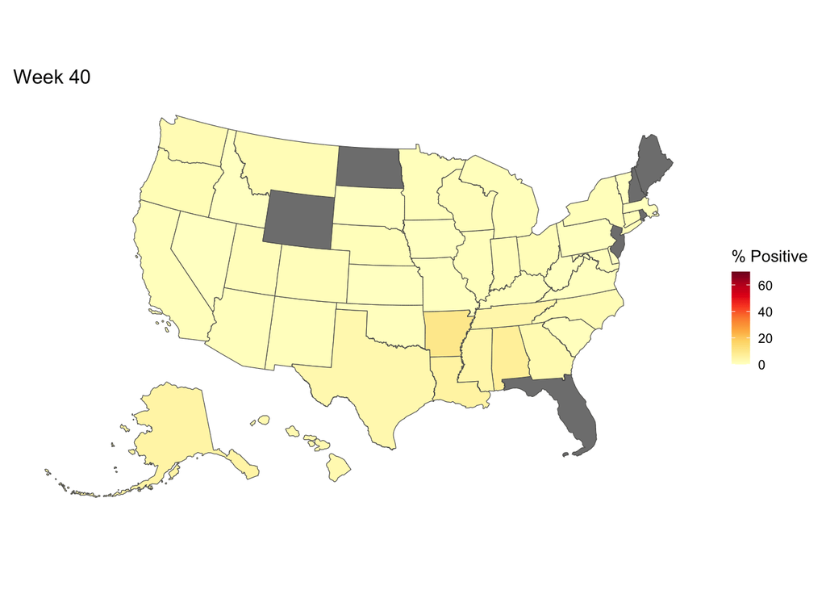

```r
# Create animation using gifski()
for (i in seq_along(season2017_map_list)) {
  print(season2017_map_list[[i]])
}
```

Next let’s take a closer look of the CDC surveillance data by state.

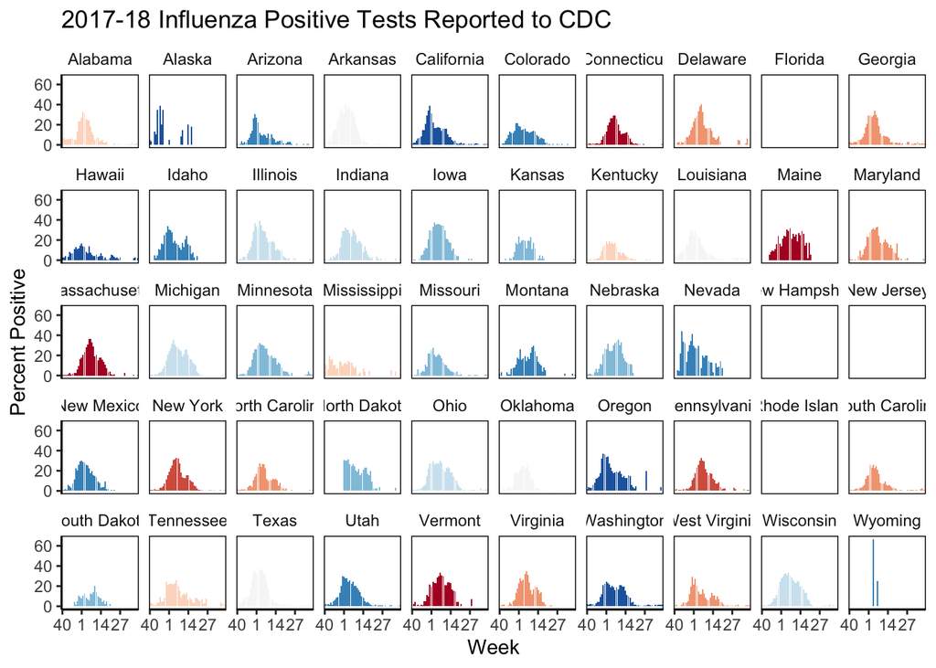

```r
# Percent positive cases in 2017-18 season
season2017 |>
  ggplot(aes(x = ordered_week, y = percent_positive, fill = division)) +
        facet_wrap(~ state, nrow = 5, ncol = 10) +
        geom_bar(stat = "identity") +
        scale_fill_brewer(palette = "RdBu") +
        scale_x_discrete(breaks = c(1, 14, 27, 40), labels = c(40, 1, 14, 27)) +
        scale_y_continuous() +
        labs(x = "Week", y = "Percent Positive", title = "2017-18 Influenza Positive Tests Reported to CDC") +
        theme_classic() +
        theme(legend.position = "none",
              strip.background = element_blank(),
              panel.border = element_rect(color = "black", fill = NA))
```

It is clear that influenza activity varied greatly across states in the 2017-18 season. States like California and Nevada had pretty early influenza detection whereas some states did not experience peak flu activity until later. There is also missing data for some of the states.

The U.S. Census Bureau has grouped the 50 states and the District of Columbia into nine divisions based on geographic proximity. I will also look at the surveillance data within each division.

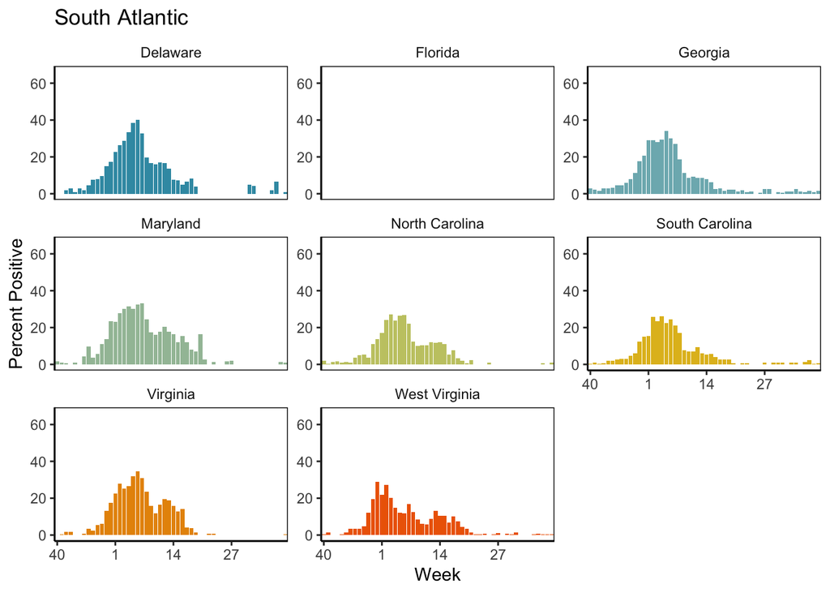

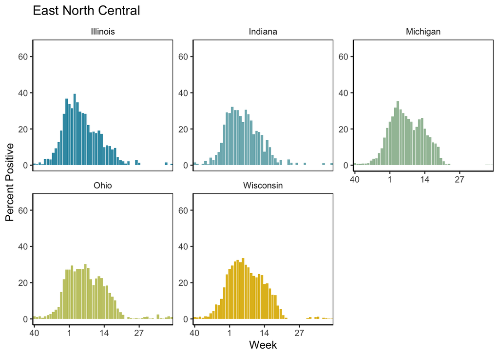

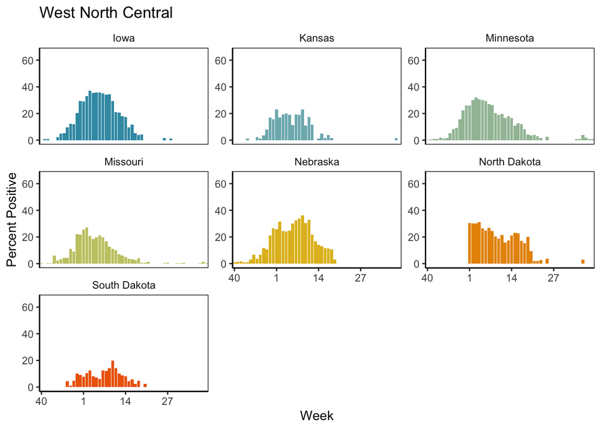

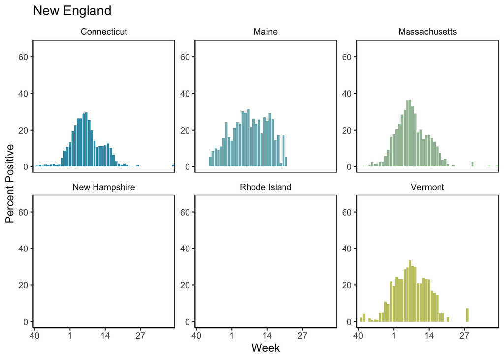

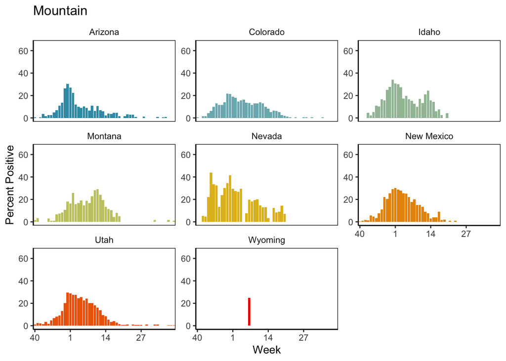

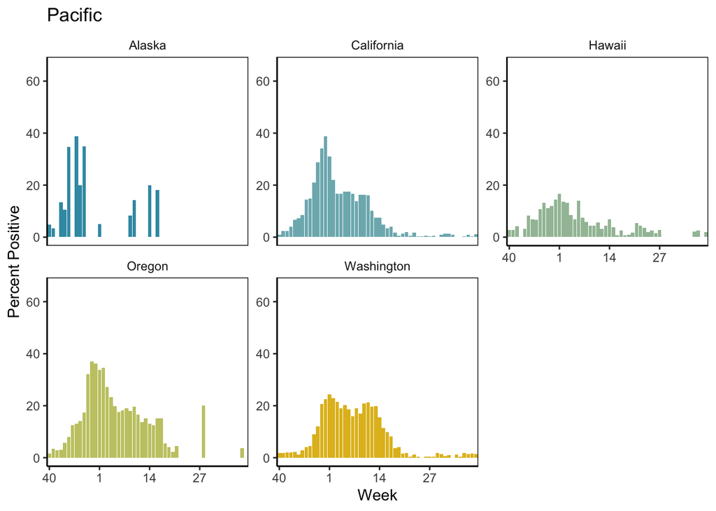

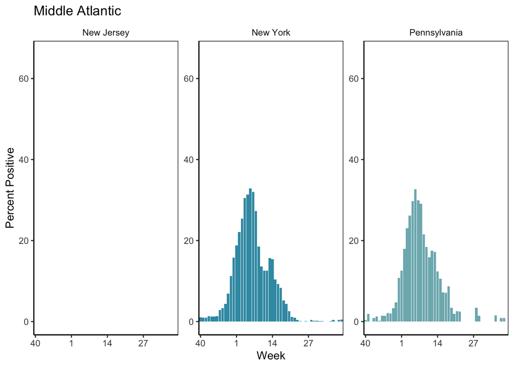

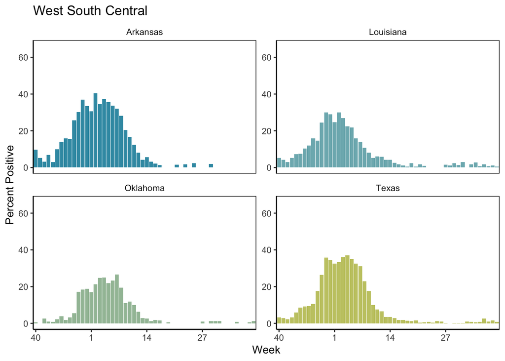

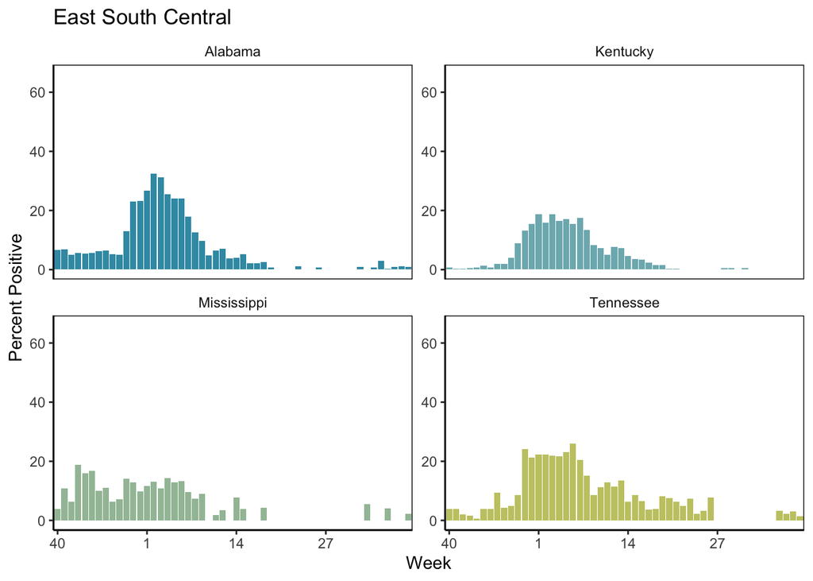

```r
# Get unique divisions
unique_divisions <- unique(season2017$division)

# Create a list to store individual plots
season2017_plot_list <- list()

# Create plots for each division
for (i in unique_divisions) {

  division_data <- season2017 |>
          filter(division == i)

  p <- ggplot(division_data, aes(x = ordered_week, y = percent_positive, fill = state)) +
    geom_bar(stat = "identity") +
    facet_wrap(~ state, scales = "free_y") +
    scale_fill_manual(values = wes_palette("Zissou1", n = 8, type = "continuous")) +
    scale_x_discrete(breaks = c(1, 14, 27, 40), labels = c(40, 1, 14, 27)) +
    scale_y_continuous() +
    ylim(0, 66) +
    labs(x = "Week", y = "Percent Positive", title = i) +
    theme_classic() +
    theme(legend.position = "none",
              strip.background = element_blank(),
              panel.border = element_rect(color = "black", fill = NA))
 season2017_plot_list[[length(season2017_plot_list) + 1]] <- p
}

print(season2017_plot_list)
```

```r
#grid.arrange(grobs = season2017_plot_list, ncol = 3)
```

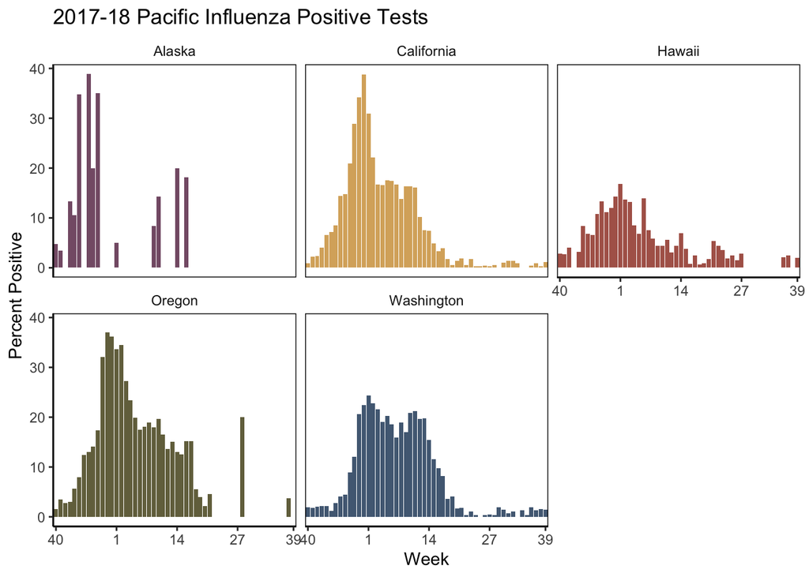

```r
# Percent positive cases in 2017-18 season in Pacific
season2017 |>
        filter(division == "Pacific") |>
        ggplot(aes(x = ordered_week, y = percent_positive, fill = state)) +
        geom_bar(stat = "identity") +
        facet_wrap(~ state) +
        #scale_fill_manual(values = wes_palette("Zissou1", n = 5, type = "continuous")) +
        scale_fill_manual(values = c('#855C75', '#D9AF6B', '#AF6458', '#736F4C', '#526A83', '#625377', '#68855C')) +
        scale_x_discrete(breaks = c(1, 14, 27, 40, 52), labels = c(40, 1, 14, 27, 39)) +
        scale_y_continuous() +
        labs(x = "Week", y = "Percent Positive", title = "2017-18 Pacific Influenza Positive Tests") +
        theme_classic() +
        theme(legend.position = "none",
              strip.background = element_blank(),
              panel.border = element_rect(color = "black", fill = NA))
```

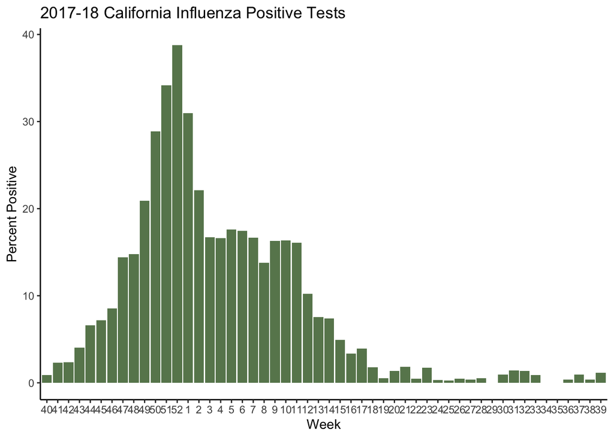

```r
# Percent positive cases in 2017-18 season in California
season2017 |>
        filter(state == "California") |>
        ggplot(aes(x = ordered_week, y = percent_positive, fill = division)) +
        geom_bar(stat = "identity") +
        scale_fill_manual(values = "#68855C") +
        scale_x_discrete(breaks = 1:52, labels = c(40:52, 1:39)) +
        scale_y_continuous() +
        labs(x = "Week", y = "Percent Positive", title = "2017-18 California Influenza Positive Tests") +
        theme_classic() +
        theme(legend.position = "none")
```

### References

U.S. Influenza Surveillance: Purpose and Methods: https://www.cdc.gov/flu/weekly/overview.htm